# IODS course project

Pauliina Anttila

# 1. Introduction to Open Data Science

This course is all about finding the joy in doing science together. It’s about learning to use open data sources with tools that are available to everyone.

https://github.com/pauliinaanttila/IODS-project

# 2. Regression and model validation

*This week we really got started with data wrangling and analysis with RStudio. I haven’t been using RStudio before, so this all has been quite exciting and challenging. After a few hours of trial and error, I’m starting to learn the basic tricks about exploring and analyzing data in RStudio.*

## Description of the data set

```r
students2014 <- read.csv (file = "~/Documents/GitHub/IODS-project/data/learning2014.csv", header = TRUE, sep = ",") # reading a CSV file named learning2014 into R
str(students2014) # exploring the structure of the data, gives the names and types of variables
```

```
## 'data.frame':    166 obs. of  7 variables:
##  $ gender  : Factor w/ 2 levels "F","M": 1 2 1 2 2 1 2 1 2 1 ...
##  $ age     : int  53 55 49 53 49 38 50 37 37 42 ...
##  $ attitude: num  3.7 3.1 2.5 3.5 3.7 3.8 3.5 2.9 3.8 2.1 ...
##  $ deep    : num  3.58 2.92 3.5 3.5 3.67 ...
##  $ stra    : num  3.38 2.75 3.62 3.12 3.62 ...
##  $ surf    : num  2.58 3.17 2.25 2.25 2.83 ...
##  $ points  : int  25 12 24 10 22 21 21 31 24 26 ...
```

```r
dim(students2014) # exploring the dimensions of the data, contains 166 observations of 7 variables
```

```
## [1] 166   7
```

**We are working with students2014 dataset this week. The dataset contains 166 students who took part in a course called Introduction to Social Statistics in fall 2014 and also attended the final exam. The variables collected to the dataset are gender, age, attitude, deep learning, strategic learning, surface learning and exam points. The attitude towards statistics and details concerning learning methods were gathered through a questionnaire.**

## Graphical overview of the data

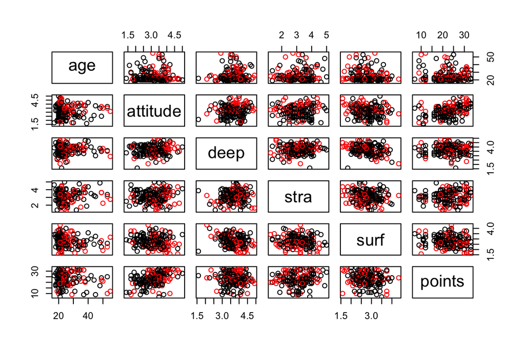

```r
pairs(students2014[-1], col = students2014$gender) # draws all possible scatter plots from the columns of a data frame, resulting in a scatter plot matrix
```

**This scatter plot matrix shows all the possible scatter plots from the columns of the students2014 data frame, but it’s a bit tricky to interpret as such.**

```r
summary(students2014)
```

```
##  gender       age           attitude          deep            stra
##  F:110   Min.   :17.00   Min.   :1.400   Min.   :1.583   Min.   :1.250
##  M: 56   1st Qu.:21.00   1st Qu.:2.600   1st Qu.:3.333   1st Qu.:2.625
##          Median :22.00   Median :3.200   Median :3.667   Median :3.188
##          Mean   :25.51   Mean   :3.143   Mean   :3.680   Mean   :3.121
##          3rd Qu.:27.00   3rd Qu.:3.700   3rd Qu.:4.083   3rd Qu.:3.625
##          Max.   :55.00   Max.   :5.000   Max.   :4.917   Max.   :5.000
##       surf           points
##  Min.   :1.583   Min.   : 7.00
##  1st Qu.:2.417   1st Qu.:19.00
##  Median :2.833   Median :23.00
##  Mean   :2.787   Mean   :22.72
##  3rd Qu.:3.167   3rd Qu.:27.75
##  Max.   :4.333   Max.   :33.00
```

**The dataset includes 110 females and 56 males. The mean age of the studied population is 25.5 years. The youngest participant has been 17 years old and the oldest 55 years old. The points for attitude vary between 1.4 and 5 with a mean of 3.14. The exam points vary between 7 and 33 with a mean of 22.7. The means for deep, strategic and surface learning are 3.7, 3.1 and 2.8, respectively.**

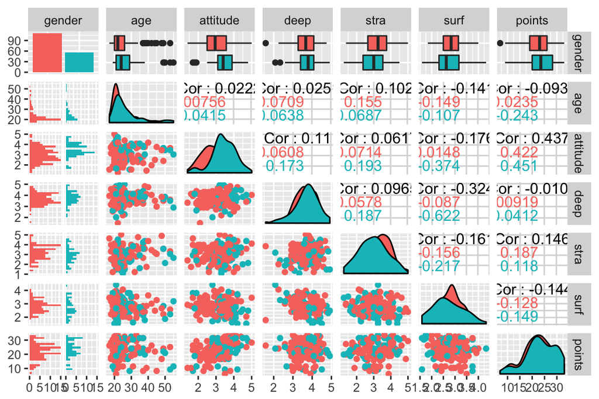

```r
library(GGally)
library(ggplot2)
p <- ggpairs(students2014, mapping = aes(col = gender), lower = list(combo = wrap("facethist", bins = 20)))
p
```

**The age of the studied population is not normally distributed, the mass of the distribution is concentrated to the left of the figure, i.e. the skewness is positive. Said simpler, in the studied population, the majority of the people are in their twenties, but there are a few people that are noticeably older as well.**

**The distributions of attitude, strategic learning and surface learning are fairly normally distributed. The distributions of deep learning and points are concentrated to the right of the figure, i.e. skewness is negative. In the case of points, there are more students that have scored well in the examination compared to those who have not done so well.**

**Male students seem to have a bit better exam points than female students. There is a mild negative correlation with age and points. Attitude seems to have a positive correlation with exam points. Strategic learning is advantageous in terms of having good exam points, surface learning has negative correlation with points.**

## Analysis of the data with regression

**Regression analysis is a statistical modelling method used to estimate the relationships among variables. The focus is on the relationship between a dependent variable (*here points*) and one or more independent variables (*here attitude, strategic learning and surface learning*).**

```r
my_model <- lm(points ~ attitude + stra + surf, data = students2014) # a multiple regression model where points is the dependent variable and attitude, strategic learning and surface learning are explanatory variables
summary(my_model)
```

```
##
## Call:
## lm(formula = points ~ attitude + stra + surf, data = students2014)
##
## Residuals:
##      Min       1Q   Median       3Q      Max
## -17.1550  -3.4346   0.5156   3.6401  10.8952
##
## Coefficients:
##             Estimate Std. Error t value Pr(>|t|)
## (Intercept)  11.0171     3.6837   2.991  0.00322 **
## attitude      3.3952     0.5741   5.913 1.93e-08 ***
## stra          0.8531     0.5416   1.575  0.11716
## surf         -0.5861     0.8014  -0.731  0.46563
## ---
## Signif. codes:  0 '***' 0.001 '**' 0.01 '*' 0.05 '.' 0.1 ' ' 1
##
## Residual standard error: 5.296 on 162 degrees of freedom
## Multiple R-squared:  0.2074, Adjusted R-squared:  0.1927
## F-statistic: 14.13 on 3 and 162 DF,  p-value: 3.156e-08
```

**In this example, the multiple regression model includes points as a dependent variable and attitude, strategic learning and surface learning as explanatory variables. The only variable that has a statistically significant relationship with points is attitude. The coefficient is 3.4 (p-value 1.93e-08) meaning that one gets better exam points with better attitude.**

```r
my_model2 <- lm(points ~ attitude, data = students2014)
summary(my_model2)
```

```
##
## Call:
## lm(formula = points ~ attitude, data = students2014)
##
## Residuals:
##      Min       1Q   Median       3Q      Max
## -16.9763  -3.2119   0.4339   4.1534  10.6645
##
## Coefficients:
##             Estimate Std. Error t value Pr(>|t|)
## (Intercept)  11.6372     1.8303   6.358 1.95e-09 ***
## attitude      3.5255     0.5674   6.214 4.12e-09 ***
## ---
## Signif. codes:  0 '***' 0.001 '**' 0.01 '*' 0.05 '.' 0.1 ' ' 1
##
## Residual standard error: 5.32 on 164 degrees of freedom
## Multiple R-squared:  0.1906, Adjusted R-squared:  0.1856
## F-statistic: 38.61 on 1 and 164 DF,  p-value: 4.119e-09
```

**It seems that better attitude gives one better results in the exam measured by points.**

**R-squared is a statistical measure of how close the data are to the fitted regression line. In general, a model fits the data well if the differences between the observed values and the model’s predicted values are small and unbiased. In general, the higher the R-squared, the better the model fits your data. The values of R-squared are between 0 and 1 (0-100 %).**

**The R-squared is moderately low here (0.19), but it is understandable given the nature of the study (any field that attempts to predict human behavior typically has R-squared values lower than 50%, humans are simply harder to predict than, say, physical processes.)**

## Diagnostic plots

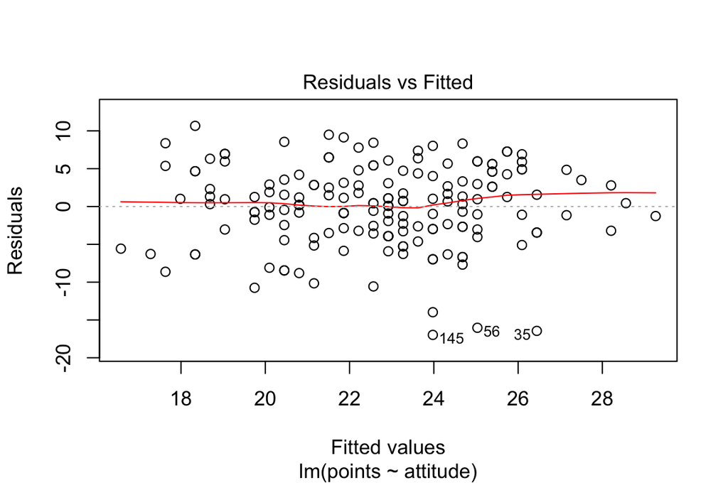

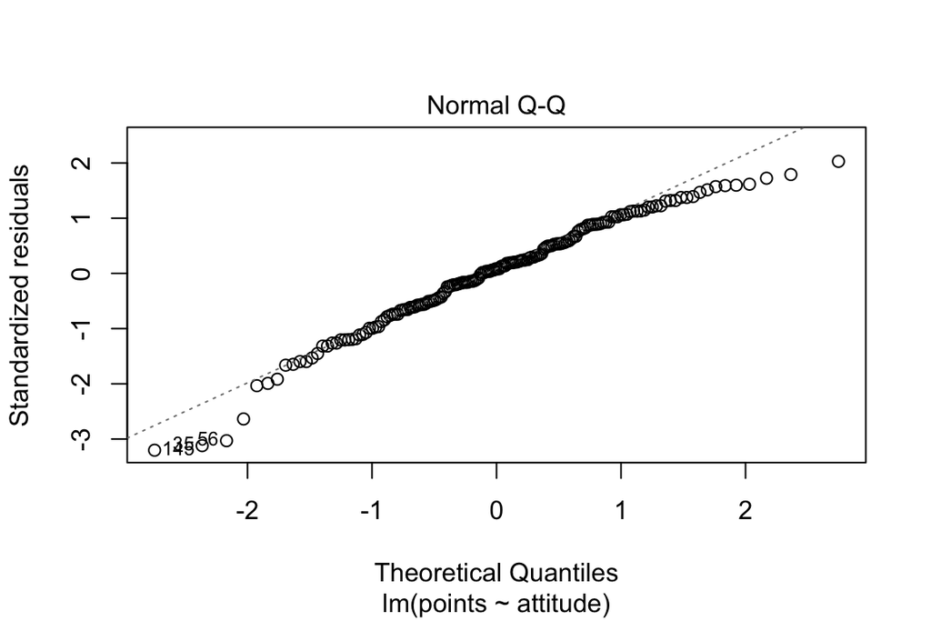

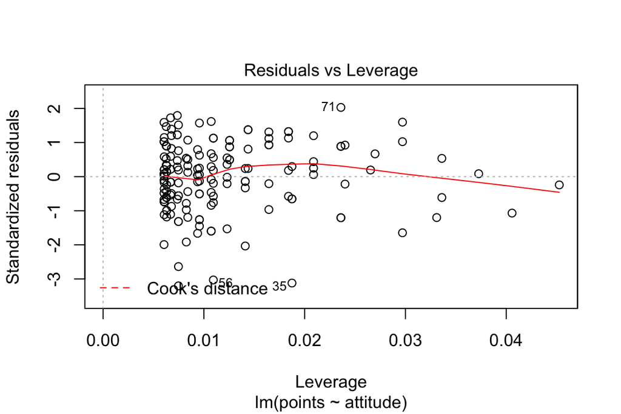

```r
plot(my_model2, which = c(1,2,5))
```

**A bit about diagnostic plots:**

**Diagnostic plots are used to test the validity of models.**

**1) Residuals vs Fitted values provides a method to explore residuals versus model predictions. With this method one can test the constant variance assumption. The constant variance assumption implies that the size of errors should not depend on the explanatory variables.**

*In this example, the assumption is reasonable (the observations reasonably randomly spread).*

**2) The QQ-plot of the residuals provides a method to explore the assumption that the errors of the model are normally distributed.**

*The QQ-plot in this example is quite reasonable, even though in both ends the observations differ from the straight line. The normality assumption is reasonable here.*

**3) Residuals versus leverage plot can help identify which observations have an unusually high impact.**

*In this example, there are no observations that would have a markably higher leverage.*

# 3. Logistic regression

## Description of the data set

**This week we are working with a joined dataset that contains two Portuguese student alcohol consumption data sets. Originally, the data sets are found from the UCI Machine Learning Repository under the name “Student performance data set” (donated Nov 2014). The original data sets contain data about student performance in secondary education of two Portuguese schools in two distinct subjects: mathematics and Portuguese language. The data was collected by using school reports and questionnaires. We wrangled the data so that we combined the data sets (mathematics and Portuguese language).**

The wrangled data set contains 382 observations of 35 variables. The variables include the following:

1 school - student’s school

2 sex - student’s sex

3 age - student’s age

4 address - student’s home address type

5 famsize - family size

6 Pstatus - parent’s cohabitation status

7 Medu - mother’s education

8 Fedu - father’s education

9 Mjob - mother’s job

10 Fjob - father’s job

11 reason - reason to choose this school

12 guardian - student’s guardian

13 traveltime - home to school travel time

14 studytime - weekly study time

15 failures - number of past class failures

16 schoolsup - extra educational support

17 famsup - family educational support

18 paid - extra paid classes within the course subject (Math or Portuguese)

19 activities - extra-curricular activities

20 nursery - attended nursery school

21 higher - wants to take higher education

22 internet - Internet access at home

23 romantic - with a romantic relationship

24 famrel - quality of family relationships

25 freetime - free time after school

26 goout - going out with friends

27 Dalc - workday alcohol consumption

28 Walc - weekend alcohol consumption

29 health - current health status

30 absences - number of school absences

31 G1 - first period grade

32 G2 - second period grade

33 G3 - final grade

34 alc_use - the average of alcohol consumption on weekdays and weekends

35 high_use - TRUE if “alc_use is higher than 2”

```r
alc <- read.csv (file = "~/Documents/GitHub/IODS-project/data/alc.csv", header = TRUE, sep = ",", dec = ".") # reading data into R
colnames(alc) # printing out the names of the variables
```

```
##  [1] "school"     "sex"        "age"        "address"    "famsize"
##  [6] "Pstatus"    "Medu"       "Fedu"       "Mjob"       "Fjob"
## [11] "reason"     "nursery"    "internet"   "guardian"   "traveltime"
## [16] "studytime"  "failures"   "schoolsup"  "famsup"     "paid"
## [21] "activities" "higher"     "romantic"   "famrel"     "freetime"
## [26] "goout"      "Dalc"       "Walc"       "health"     "absences"
## [31] "G1"         "G2"         "G3"         "alc_use"    "high_use"
```

```r
dim(alc) # there are 382 observations of 35 variables in the data
```

```
## [1] 382  35
```

```r
str(alc)
```

```
## 'data.frame':    382 obs. of  35 variables:
##  $ school    : Factor w/ 2 levels "GP","MS": 1 1 1 1 1 1 1 1 1 1 ...
##  $ sex       : Factor w/ 2 levels "F","M": 1 1 1 1 1 2 2 1 2 2 ...
##  $ age       : int  18 17 15 15 16 16 16 17 15 15 ...
##  $ address   : Factor w/ 2 levels "R","U": 2 2 2 2 2 2 2 2 2 2 ...
##  $ famsize   : Factor w/ 2 levels "GT3","LE3": 1 1 2 1 1 2 2 1 2 1 ...
##  $ Pstatus   : Factor w/ 2 levels "A","T": 1 2 2 2 2 2 2 1 1 2 ...
##  $ Medu      : int  4 1 1 4 3 4 2 4 3 3 ...
##  $ Fedu      : int  4 1 1 2 3 3 2 4 2 4 ...
##  $ Mjob      : Factor w/ 5 levels "at_home","health",..: 1 1 1 2 3 4 3 3 4 3 ...
##  $ Fjob      : Factor w/ 5 levels "at_home","health",..: 5 3 3 4 3 3 3 5 3 3 ...
##  $ reason    : Factor w/ 4 levels "course","home",..: 1 1 3 2 2 4 2 2 2 2 ...
##  $ nursery   : Factor w/ 2 levels "no","yes": 2 1 2 2 2 2 2 2 2 2 ...
##  $ internet  : Factor w/ 2 levels "no","yes": 1 2 2 2 1 2 2 1 2 2 ...
##  $ guardian  : Factor w/ 3 levels "father","mother",..: 2 1 2 2 1 2 2 2 2 2 ...
```

[output cut: 21 more lines]

## Exploring the data set

### My hypotheses:

*1. Older students consume high amounts of alcohol more often than younger ones.*

*2. Those who have high use of alcohol tend to fail more often.*

*3. Those who have extra-curricular activities consume less alcohol.*

*4. Those who want to take higher education consume less alcohol.*

**1. Age and alcohol consumption:**

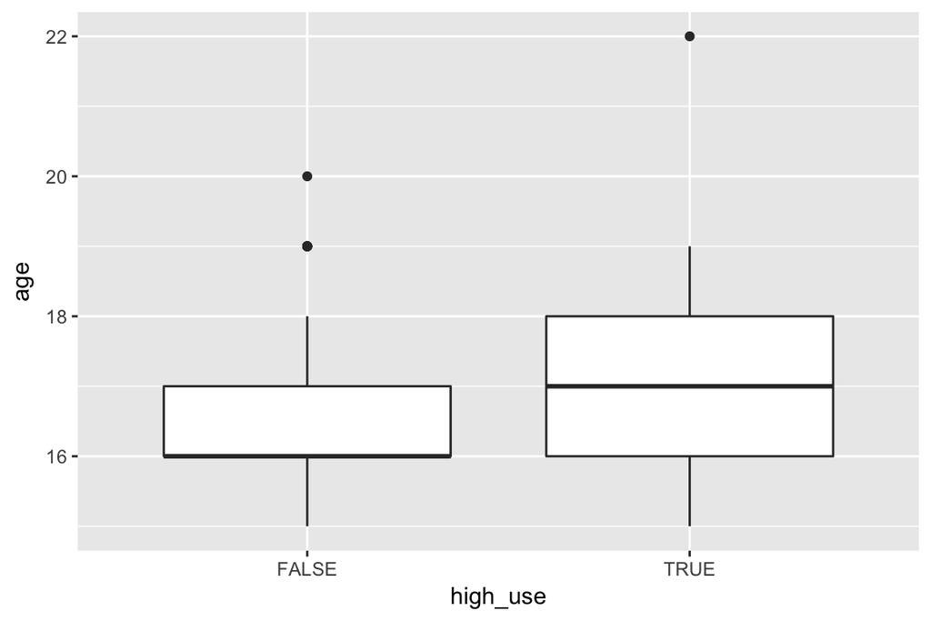

```r
library(ggplot2)
p1 <- ggplot(alc, aes(x = high_use, y = age))
p1 + geom_boxplot() + ylab("age")
```

```r
t1 <- table(alc$high_use, alc$age) # crosstabulation of "high_use" and "age"
t1
```

```
##
##         15 16 17 18 19 20 22
##   FALSE 63 79 64 54  7  1  0
##   TRUE  18 28 36 27  4  0  1
```

**According to the boxplots and crosstabulation, it seems that older students consume high amounts of alcohol more often than the younger ones.**

**2. Alcohol consumption and failures:**

```r
t2 <- table(alc$high_use, alc$failures) # crosstabulation of "high_use" and "failures"
t2
```

```
##
##           0   1   2   3
##   FALSE 244  12  10   2
##   TRUE   90  12   9   3
```

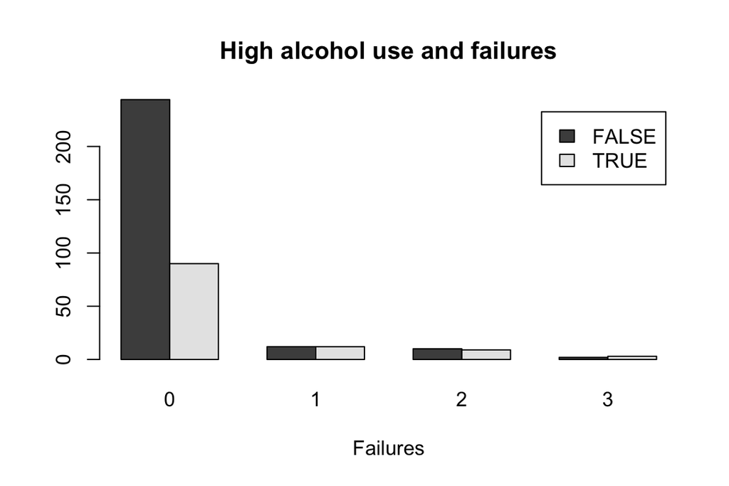

```r
counts <- table(alc$high_use, alc$failures)
barplot(counts, main="High alcohol use and failures",
  xlab="Failures",
    legend = rownames(counts), beside=TRUE)
```

Number of failures in the x-axis and count of students on the y-axis. Grouped by “high_use” (either TRUE or FALSE).

**Only a small proportion of students have failed and the absolute counts of failures are fairly similar in both groups (those who use high amounts of alcohol vs those who do not). It is to be noted, that there is a lot more students in the latter group (268 vs 114).**

**3. Alcohol consumption and activities:**

```r
t3 <- table(alc$high_use, alc$activities)
t3
```

```
##
##          no yes
##   FALSE 122 146
##   TRUE   59  55
```

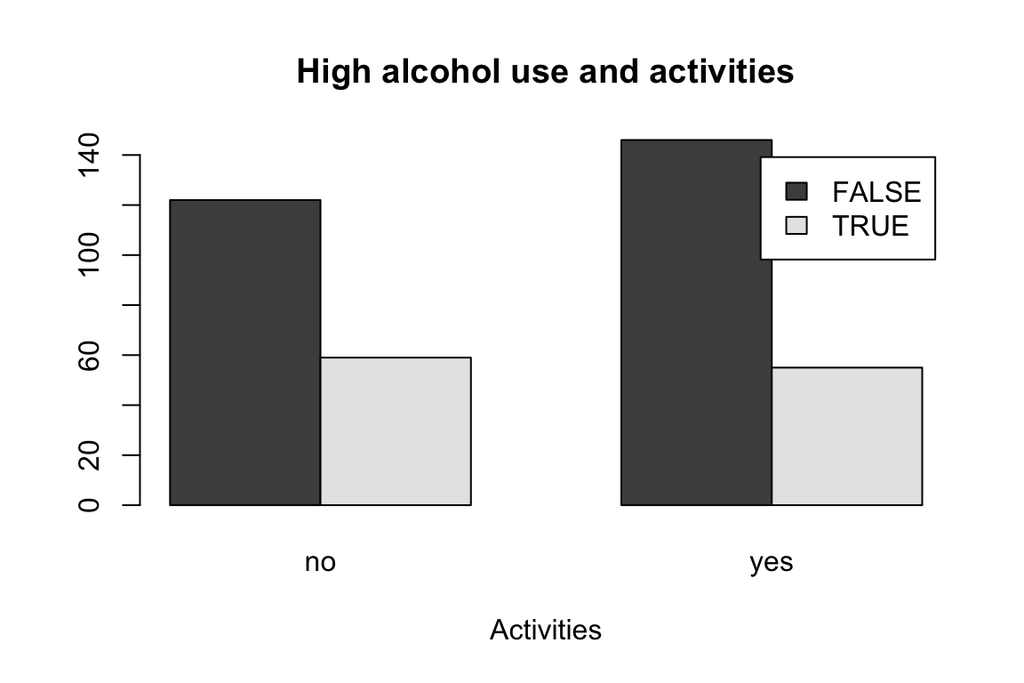

```r
counts <- table(alc$high_use, alc$activities)
barplot(counts, main="High alcohol use and activities",
  xlab="Activities",
    legend = rownames(counts), beside=TRUE)
```

**The proportion of students who consume high amounts of alcohol is bigger in the group that has no activities.**

**4. Alcohol consumption and the urge to take higher education:**

```r
t4 <- table(alc$high_use, alc$higher)
t4
```

```
##
##          no yes
##   FALSE   9 259
##   TRUE    9 105
```

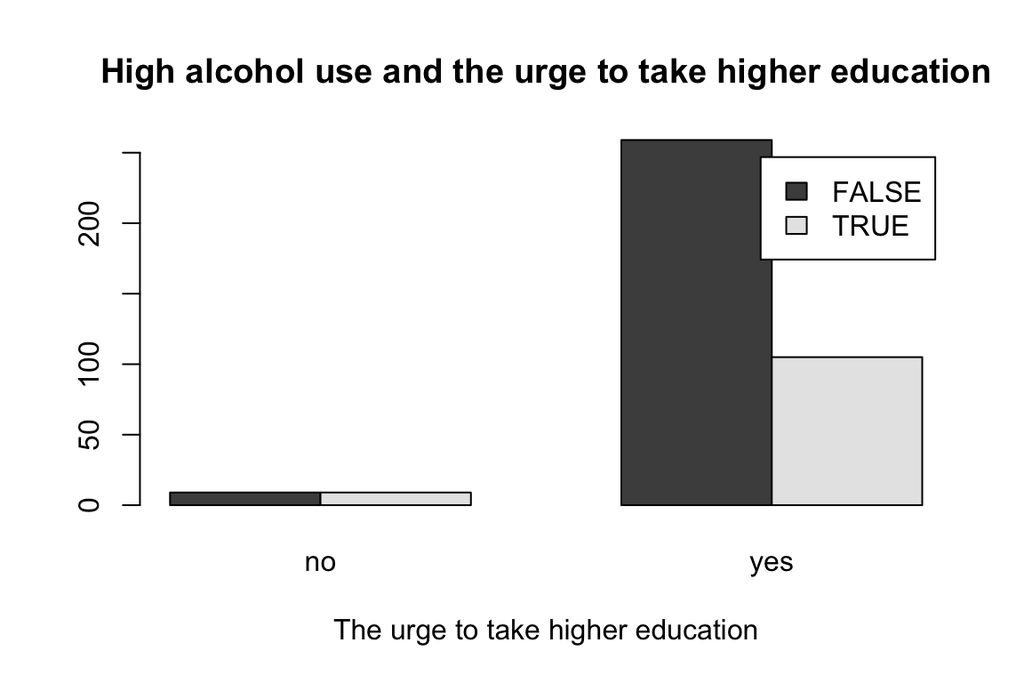

```r
counts <- table(alc$high_use, alc$higher)
barplot(counts, main="High alcohol use and the urge to take higher education",
  xlab="The urge to take higher education",
    legend = rownames(counts), beside=TRUE)
```

**The majority of the students want to take higher education.**

## Analysis with logistic regression

```r
library(dplyr)
my_model <- glm (formula = high_use ~ age + failures + activities + higher, data = alc, family ="binomial") # Logistic regression model with high_use as target variable and age, failures, activities and higher education target as explanatory variables.
summary(my_model)
```

```
##
## Call:
## glm(formula = high_use ~ age + failures + activities + higher,
##     family = "binomial", data = alc)
##
## Deviance Residuals:
##     Min       1Q   Median       3Q      Max
## -1.4581  -0.8444  -0.7406   1.3466   1.7584
##
## Coefficients:
##               Estimate Std. Error z value Pr(>|z|)
## (Intercept)    -3.1430     1.8387  -1.709   0.0874 .
## age             0.1528     0.1003   1.523   0.1279
## failures        0.4397     0.1948   2.257   0.0240 *
## activitiesyes  -0.1820     0.2290  -0.795   0.4266
## higheryes      -0.2731     0.5435  -0.503   0.6153
## ---
## Signif. codes:  0 '***' 0.001 '**' 0.01 '*' 0.05 '.' 0.1 ' ' 1
##
## (Dispersion parameter for binomial family taken to be 1)
##
##     Null deviance: 465.68  on 381  degrees of freedom
## Residual deviance: 453.19  on 377  degrees of freedom
## AIC: 463.19
##
## Number of Fisher Scoring iterations: 4
```

```r
coef(my_model) # coefficients of the model
```

```
##   (Intercept)           age      failures activitiesyes     higheryes
##    -3.1429502     0.1527828     0.4397280    -0.1820300    -0.2731132
```

```r
OR <- coef(my_model) %>% exp # computing odds ratios
CI <- confint(my_model) %>% exp # computing confidence intervals
cbind(OR,CI) # printing ORs and CIs
```

```
##                      OR       2.5 %   97.5 %
## (Intercept)   0.0431553 0.001136953 1.561687
## age           1.1650719 0.957724023 1.420525
## failures      1.5522849 1.059603697 2.289548
## activitiesyes 0.8335763 0.531757595 1.306573
## higheryes     0.7610067 0.262896907 2.277735
```

**The previous data exploring and logistic regression model show similar trends with other variables, but they are not statistically significant.**

## Exploring the predictive power of my model

```r
my_model2 <- glm(high_use ~ failures, data = alc, family = "binomial") # fitting the model with the only variable (failures) that had statistically significant relationship with high use of alcohol
probabilities <- predict(my_model2, type = "response") # predicting the probability of high use
alc <- mutate(alc, probability = probabilities) # adding the predicted probabilities to 'alc'
alc <- mutate(alc, prediction = probability > 0.5) # using the probabilities to make a prediction of high_use
table(high_use = alc$high_use, prediction = alc$prediction) # tabulation of the target variable versus the predictions
```

```
##         prediction
## high_use FALSE TRUE
##    FALSE   256   12
##    TRUE    102   12
```

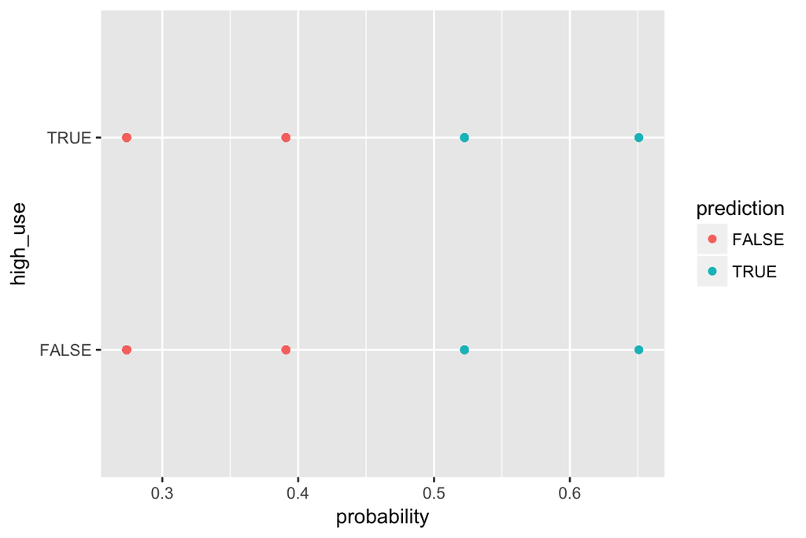

```r
library(dplyr)
library(ggplot2)
g <- ggplot(alc, aes(x = probability, y = high_use, col = prediction)) # initializing a plot of 'high_use' versus 'probability' in 'alc'
g + geom_point() # defining the geom as points and drawing the plot
```

```r
table(high_use = alc$high_use, prediction = alc$prediction) %>% prop.table() %>% addmargins() # tabulating the target variable versus the predictions
```

```
##         prediction
## high_use      FALSE       TRUE        Sum
##    FALSE 0.67015707 0.03141361 0.70157068
##    TRUE  0.26701571 0.03141361 0.29842932
##    Sum   0.93717277 0.06282723 1.00000000
```

```r
loss_func <- function(class, prob) {
  n_wrong <- abs(class - prob) > 0.5
  mean(n_wrong)
} # defining a loss function (mean prediction error)
loss_func(class = alc$high_use, prob = alc$probability) # calling loss_func to compute the average number of wrong predictions in the (training) data
```

```
## [1] 0.2984293
```

**The average amount of wrong predictions in the (training) data is 29,8%. The proportion is quite high but still better than pure quessing.**